# Travis Scott

Author

Angad Dhaliwal Chandra

# Cactus Jack

## Background

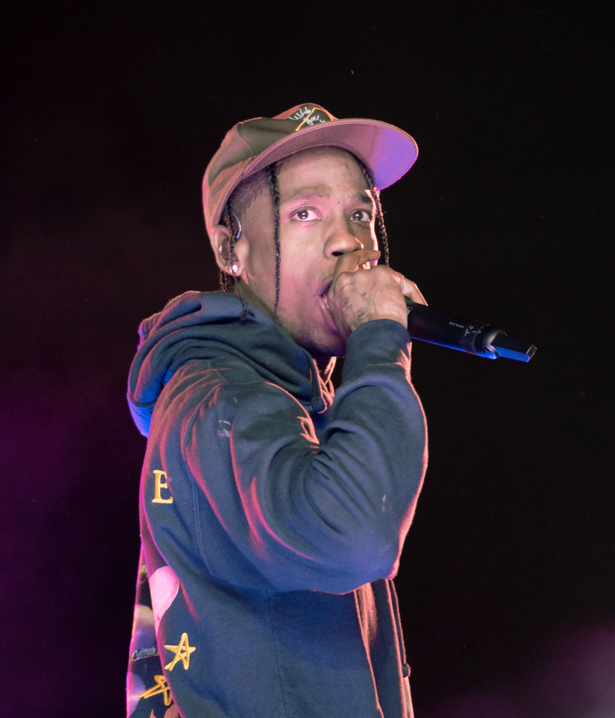

Travis Scott

Jacques Webster II, whose stage name is Travis Scott, is an American rapper and producer. His music has garnered over 62.5 billion streams with 37 million followers on Spotify. Scott majorly creates hip-hop music with strong trap influences, where he adds psychedelic, ambient and electronic elements into his music.

Opening line to my favourite Travis Scott song, *Nightcrawler*:

> “Order more bottles”

> - Travis

Hailing from Houston, his major musical influences are Kid Cudi, Kanye West and OutKast for different parts of his production, lyrics and vocals. Scott’s biggest hits include goosebumps, SICKO MODE, HIGHEST IN THE ROOM and FE!N.

## Career

### 2012-2014: Mixtapes

This was the start of Scott’s music career with two major mixtapes being released; ‘Owl Pharaoh’ and ‘Days Before Rodeo’. These mixtapes were quite critically acclaimed due to the artist’s new psychedelic trap style which later became Scott’s signature sound. This period also saw a lot of initial project collaboration with mainstream and up-and-coming artists such as Kanye West, Young Thug and Mike Dean.

**Releases**:

- *Owl Pharaoh*
- *Days Before Rodeo*

[figure not shown]

Days Before Rodeo

One of my favourite songs of his from this period:

[video not shown]

### 2015-2017: Breakthrough

2015 saw the release of Scott’s first album and critically claimed, ‘Rodeo’. This song went third on the Billboard Top 200 with big-hit songs like Antidote and Nightcrawler. Shortly after its rlease, Scott released another album in 2016 named ‘Birds in the Trap Sing McKnight’. The big song from this was ‘goosebumps’ which is Scott’s most streamed song to this day. Both of these albums had a strong notes of that psychedelic-like trap sound, building from mixtapes from previous years. Scott additionally experimented a lot with auto-tune, particularly some melodic verses in his songs.

**Releases**:

- *Rodeo* (2015)
- *Birds in the Trap Sing McKnight* (2016)

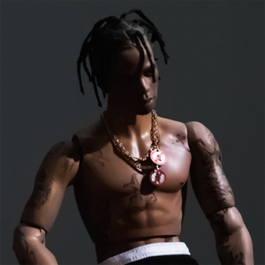

Rodeo

My favourite song in Scott’s discography was in *Rodeo*:

[video not shown]

### 2018-2020: An Established Artist

Previous album releases brought a lot of attention onto Travis’ music, however, he was yet to release an album which would cement his place as a household name in rap. This came with ‘Astroworld’ in 2018. The album debuted at number one at the Billboard 200 with huge hits like ‘SICKO MODE’ featuring Drake and ‘BUTTERFLY EFFECT’, with the former achieving diamond certification. The following year saw Scott releasing a collaborative album with former members of his self-found record label, Cactus Jack (also a nickname for Scott). This album was titled ‘JACKBOYS’ featuring now-established artists as Don Toliver and Sheck Wes.

**Releases**:

- *Astroworld* (2018)
- *JACKBOYS* (2019)

[figure not shown]

JACKBOYS

A song that truly encapsulates Travis Scott’s psychedelic style:

[video not shown]

### 2021-Present: Recent Years

Following the release of JACKBOYS, Scott took a four-year hiatus from music culminating in the release of the highly-anticipated ‘UTOPIA’. This, again, was a huge hit with songs like FE!N and Meltdown featuring Drake again. 2025 saw the release of another collaborative album between members of Cactus Jack, JACKBOYS 2. While this was highly anticipated, many musical performances within the album were deemed sub-par by many.

**Releases**:

- *UTOPIA* (2023)
- *JACKBOYS 2* (2025)

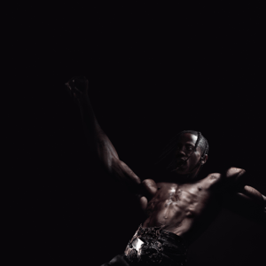

UTOPIA

Out of the entire JACKBOYS 2 album, I only liked one song:

[video not shown]

## An Analysis

To understand the difference in musical releases, the following albums will be chosen:

1. *Rodeo* (2015)
2. *Astroworld* (2018)
3. *UTOPIA* (2023)

I imported the data from Spotify’s `singers_2023` dataset. The different variables and their changes will also be associated with major events Scott’s life.

```r
# Loading packages onto R
library(dplyr)
library(ggplot2)

# Importing data into RStudio
library(readr)
Travis_Scott <- read_csv("Travis_Scott.csv")
View(Travis_Scott)

# Creating Sub-Dataset for Rodeo, ASTROWORLD and UTOPIA Albums only
rodeo_astroworld_utopia <- Travis_Scott %>%
  filter(!album_name %in% c("Huncho Jack, Jack Huncho", "JACKBOYS", "Birds In The Trap Sing McKnight"))
```

### Valence

Valence is a metric used by Spotify to assign musical postivity to songs. This metric is measured from 0.0 to 1.0, with a value of 1 being a very positive song. Below we can see a boxplot of different valence levels from the chosen three albums.

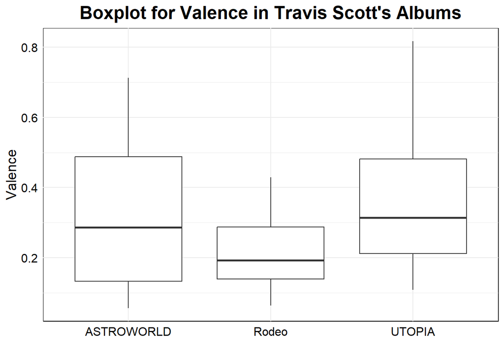

```r
# Box Plot for Rodeo
ggplot(rodeo_astroworld_utopia, aes(x = album_name, y = valence)) +
  geom_boxplot() +
  labs(title = "Boxplot for Valence in Travis Scott's Albums",
       x = "",
       y = "Valence") +
  theme_minimal() +
  theme(
    plot.background = element_rect(fill = "white", color = NA),
    panel.background = element_rect(fill = "white"),
    plot.title = element_text(
      hjust = 0.5,
      size = 18,
      color = "black",
      face = "bold"
    ),
    axis.title = element_text(color = "black", size = 14),
    axis.text = element_text(color = "black", size = 12)
  )
```

We can also see the trend of valence distribution in the chosen albums through a histogram.

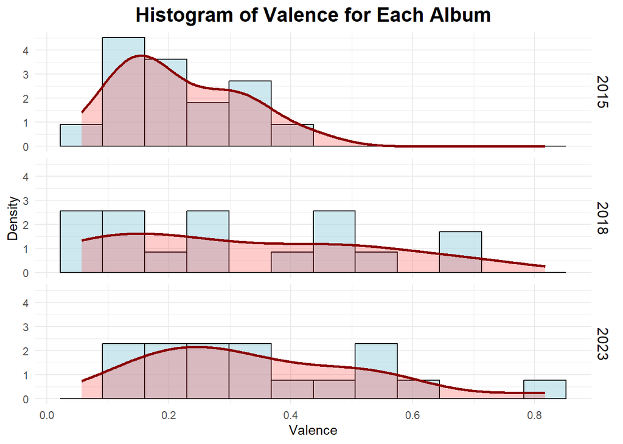

```r
# Histogram comparing valence by release year
ggplot(rodeo_astroworld_utopia, aes(x = valence)) +
  geom_histogram(aes(y = ..density..),
                 bins = 12,
                 fill = "lightblue",
                 color = "black",
                 alpha = 0.6) +
  geom_density(color = "darkred",
               fill = "red",
               alpha = 0.2,
                size = 1) +
  facet_wrap(~ album_release_year, ncol = 1, strip.position = "right") +
  labs(title = "Histogram of Valence for Each Album",
       x = "Valence",
       y = "Density") +
  theme_minimal() +
  theme(
    plot.title = element_text(hjust = 0.5, size = 16, face = "bold"),
    strip.text = element_text(size = 12)
  )
```

### Energy

Energy is a metric by Spotify that measures the intensity and activity level of a track. This, same as valence, is measured on a scale from 0.0 to 1.0, with 1 being a highly energetic song.

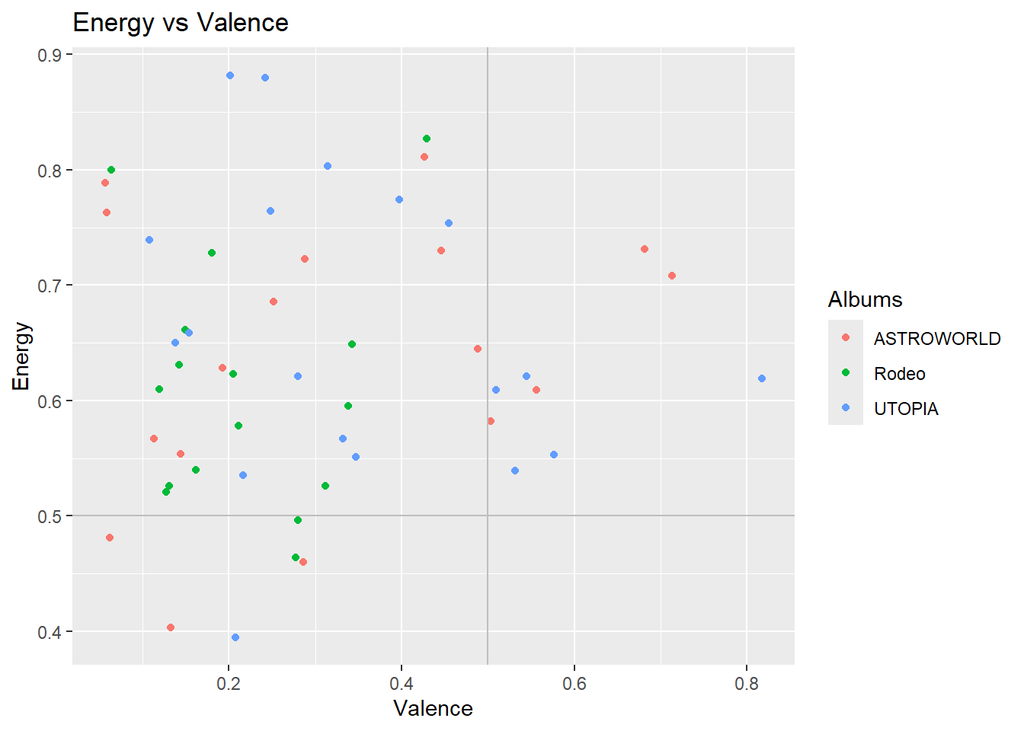

```r
# Energy vs valence
ggplot(rodeo_astroworld_utopia, aes(x = valence, y = energy, color = album_name)) +
  geom_point() +
  geom_hline(yintercept = 0.5, color = "grey") +
  geom_vline(xintercept = 0.5, color = "grey") +
  labs(
    title = "Energy vs Valence",
    x = "Valence",
    y = "Energy",
    color = "Albums")
```

Through the distribution of songs, we can see that Scott’s music is generally high in energy but low in valence apart from certain songs which have a high valence in energy. However, there are six songs with relatively low energy as well. Three are from Astroworld, two from Rodeo and one from UTOPIA. Interestingly, the song with the lowest energy as well as the song with the highest energy are from the same album (PARASAIL and FE!N from *UTOPIA*).

### Instrumentalness

Instrumentalness is a Spotify metric which highlights the amount of vocals a song has, on the same scale as previous metrics. A song closer to 1 indicates mostly an instrumental with limited vocals.

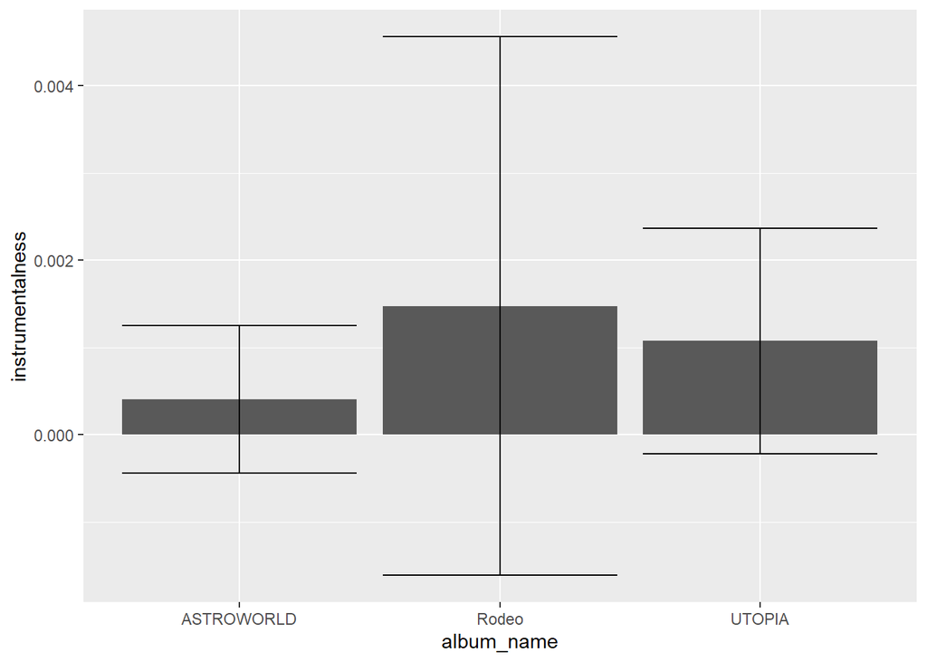

```r
# Boxplot of Instrumentalness
ggplot(rodeo_astroworld_utopia, aes(x = album_name, y = instrumentalness)) +
         stat_summary(fun = mean, geom = "bar") +
         stat_summary(fun.data = mean_cl_normal, geom = "errorbar")
```

Using all the data seen so far, we can clearly see a trend where Rodeo, Scott’s first album, has a larger amount of instrumentalness, lower valence and a medium amount of energy. Both Astroworld and UTOPIA have a similar variance in energy, instrumentalness and valence.

A reason for this can be that Scott’s first albums heavily focussed on his signature melodic and psychedelic sound and yet as he became a bigger artist (and more mainstream), he started moving further away from his sound. As a fan of Scott’s music, I can both agree and disagree with what the data shows. While I do feel his first albums are closer to the sound that he is associated with, he has tried to replicate that with only one or two songs from the following albums.